# Optimal size of subsamples

Niklas Hartung

2023-10-27

## Aim

Determine the optimal subsample size in the subsampling procedure.

### Preliminaries

```r
library(kldest)
```

## Visual inspection

To start with, I take a small set $b_1, ..., b_K$ and visualize the subsampling CIs gaphically.

```r
n <- 100
X <- rnorm(n)
Y <- rnorm(n, mean = 1, sd = 2)

kld_true <- kld_gaussian(mu1 = 0, sigma1 = 1, mu2 = 1, sigma2 = 2^2)

# Geometrically spaced subsample sizes, as in Bichel and Sakov (2008)
q <- 0.9
s_vec <- unique(floor(q^(1:20)*n))
nexpo <- length(s_vec)
res <- vector(length = nexpo, mode = "list")
for (i in 1:nexpo) {
    set.seed(1)
    res[[i]] <- kld_ci_subsampling(X = X, Y = Y, subsample.size = function(x) s_vec[i])
}
```

Graphical representation

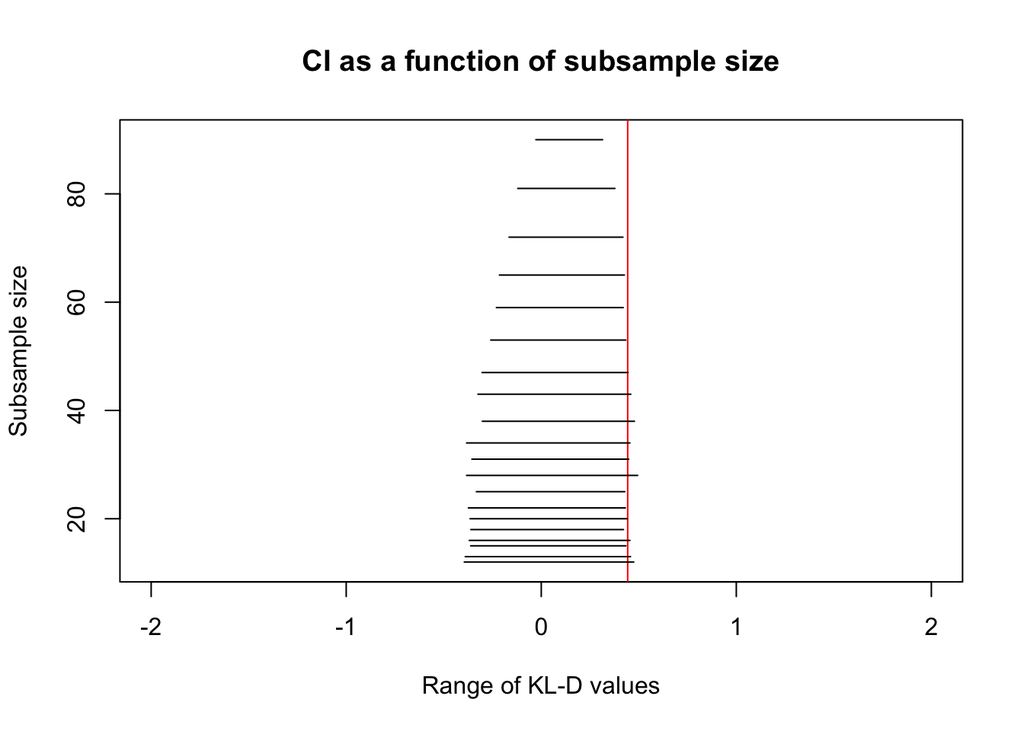

```r
plot(NA, xlim = c(-2,2), ylim = range(s_vec) + c(-0.5,0.5),
     main = "CI as a function of subsample size",
     xlab = "Range of KL-D values", ylab = "Subsample size")
abline(v = kld_true, col = "red")
for (i in 1:nexpo) {
    lines(x = unname(res[[i]]$ci), y = rep(s_vec[i],2))
}
```

$\Rightarrow$ pretty stable, unless the subsample size is really large.

## Theories for picking a subsample size

### Politis et al. (2001)

We use “Algorithm 6.1” from Politis et al. (2001), “On the asymptotic theory of subsampling”, which consists of the following steps:

- Compute subsampling intervals $I_i=[l_i,u_i]$ for different subsample sizes $b_1, ..., b_K$.
- For $i \in \{k+1,...,K-k\}$, compute the “volatility index” $v_i = \text{sd}(l_{i-k},...,l_{i+k}) + \text{sd}(l_{i-k},...,l_{i+k})$
- Select the subsample size with the lowest volatility index.

In the original procedure, $b_i = B_\text{min}+i-1$, i.e. *all subsample sizes* between $B_\text{min}$ and $B_\text{max} = B_\text{min}+K-1$ are explored. Since that seems like too much effort, I’ve rather taken a selection of values, as also done in Bichel and Sakov (2008).

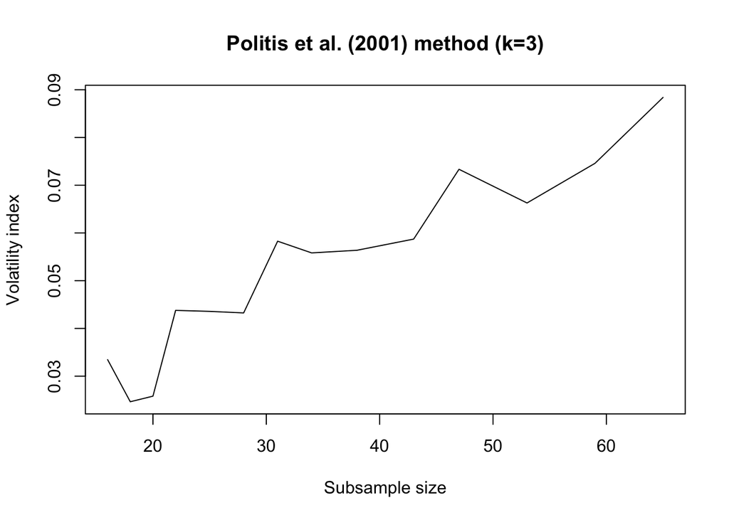

```r
li <- vapply(res, function(x) x$ci[1], 1)
ui <- vapply(res, function(x) x$ci[2], 1)

k <- 3
trimmed_sd <- function(x, k) {
    n <- length(x)
    nout <- n-2*k
    xout <- numeric(nout)
    for (i in 1:nout) {
        xout[i] <- sd(x[i+1:(2*k)])
    }
    xout
}

vi <- trimmed_sd(li, k = k) + trimmed_sd(ui, k = k)

trim <- function(x, k) tail(head(s_vec,-k),-k)

plot(trim(s_vec,k), vi, type = "l", xlab = "Subsample size",
     ylab = "Volatility index", main = paste0("Politis et al. (2001) method (k=",k,")"))
```

$\Rightarrow$ this seems very rough, not a good idea to search for a minimum…!?

### Bickel and Sakov (2008)

Bickel and Sakov (2008) uses the empirical cdf of the bootstrap replicates:

- For a fixed $0<q<1$, let $b_k = q^k n$ for $k=0,1,2,...$
- For each $k$, determine the empirical cdf $\hat F_{b_k}$ of $B>>1$ the subsampling estimates with subsample size $b_k$
- For $k=1,2,...$, compute $\sup_x|F_{b_{k-1}}(x)-F_{b_k}(x)|$
- Choose $k$ for which this functional is smallest.

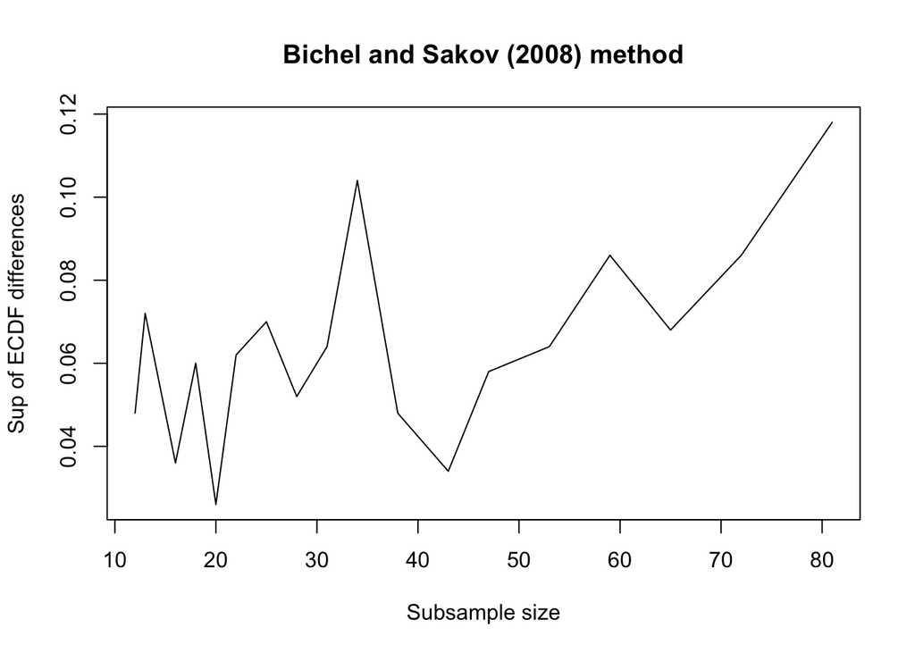

```r
ecdflist <- lapply(res, function(x) ecdf(x$boot))
xmin <- min(vapply(res, function(x) min(x$boot),1))
xmax <- max(vapply(res, function(x) max(x$boot),1))
xeval <- seq(xmin, xmax, length = 100)
mat <- vapply(ecdflist, function(x) x(xeval), xeval)
dmat <- abs(diff(t(mat)))
maxdmat <- apply(dmat, 1, max)

plot(tail(s_vec,-1), maxdmat, type = "l", xlab = "Subsample size",
     ylab = "Sup of ECDF differences", main = "Bichel and Sakov (2008) method")
```